# Wall sales prediction

```python
##### modules

import numpy as np
import pandas as pd
import matplotlib.pyplot as plt
from numpy.linalg import inv
```

## Data structure

the data are time series of historical sales for different department at different stores although accompanied to these set are other informations that can be considered in correlation to the sales of a given department, we only filter out one department in one single store and work on a model based only on the historical sales of this department.

## Filtering for a department in a particular store

So we first take a look at a department (dept number four and store number ten). Some of the data of this department are shown below. We have the store number, the department number, and the date of the reported sales that are weekly. Also additional info regarding the Holidays (which I am not using):

```python
 def filter_for_store_dept(store_num, dept_num, train_data):
    store_data = train_data.loc[train_data['Store']==store_num]
    dept_data = store_data.loc[store_data['Dept']==dept_num]
    return dept_data

filename='train.csv'
raw_data = pd.read_csv(filename)
raw_data.head()

dept_num = 4
store_num = 10

dept_data=filter_for_store_dept(store_num, dept_num, raw_data)
print dept_data.head()
```

```
       Store  Dept        Date  Weekly_Sales  IsHoliday
87953     10     4  2010-02-05      51885.86      False
87954     10     4  2010-02-12      49359.18       True
87955     10     4  2010-02-19      50350.28      False
87956     10     4  2010-02-26      51206.84      False
87957     10     4  2010-03-05      50641.43      False
```

## Objective and the data

The given sales are from $\mathbf{2010-02-05}$ until $\mathbf{2012-10-26}$ and reported weekly.

#### Objective

So, we want to split the data in two sets one running from $\mathbf{2010-02-05}$ up to $\mathbf{100}$ weeks and one running from week $\mathbf{100}$ to the end which is $\mathbf{2012-10-26}$. The latter had $\mathbf{39}$ weeks. To be generic, I use $\mathbf{T}$ for the length of the period we are interested $\mathbf{t}$ forecast.

The first set is used to train a model and the second set is assumed to be the test set where we predict its sales using the trained model.

## Methodology

Also I am going to pick a period ${\bf t_0 - T}$ up to ${\bf t_0 }$ and assume that the sales from ${\bf t_0 - T }$ up to ${ \bf t_0 }$ (regressors) predict the sales in ${\bf t_0}$ up to ${\bf t_0+T}$ (targets).

In the first ${\bf 100 }$ weeks (our training set) we could construct $\mathbf{num_{train} = 22}$ rows of observations that is: \begin{eqnarray} \\ \mathbf{X} = \begin{bmatrix} 1 & 1 & \dots \\ x_0^{t_0} & x_0^{t_0 + 1} & \dots \\ \vdots & \vdots & \dots \\ x_{-T}^{t_0} & x_{-T}^{t_0 + 1} & \dots \end{bmatrix} \end{eqnarray}

\begin{eqnarray} \\ \mathbf{Y} = \begin{bmatrix} y_T^{t_0} & y_T^{t_0 + 1} & \dots \\ \vdots & \vdots & \dots \\ y_{0}^{t_0} & y_{0}^{t_0 + 1} & \dots \end{bmatrix} \end{eqnarray}

The model is defined as a set of parameters $\theta$ such that: \begin{eqnarray} \\ \mathbf{\theta}_{ij} \mathbf{X}_{jm} = \mathbf{Y}_{im} + \mathbf{\epsilon}_{im} \end{eqnarray}

Obviously we do not no first hand what the ranges of these parameters (${\bf \theta_{ij} }$) are. Also the number of them are pretty much high. **So, I Assume that the parameters (${\bf \theta_{ij} }$) can be considered discrete values and I specify a default upper and lower bond. These parameters, physically take the form af a classical spins. Each spin takes an $N$ discrete values. Finally a Monte Carlo simulation is used to find the ground state of the spins, assuming a energy (the error function). The energy (or the error):** \begin{eqnarray} \\ \mathbf{H} = \sqrt{\mathbf{\epsilon} ^{T} \,\, . \,\, \mathbf{\epsilon}} \end{eqnarray}

## Functions Used in the simulation:

### The following functions are used and their description is provided as well:

```python
'''
 Here are the function used todo the optimization:
 1) getError(theta, X, Y) is basically the hamiltonian of the model. It takes observations X and Y in and compute
     the hamiltoninan (error) given a set of theta parameters or physically a set of spin configurations "theta".
'''
def getError(theta, X, Y):
    E = (theta.dot(X) - Y)
    E = E.ravel()
    return np.sqrt(E.dot(E.transpose())[0,0])

'''
2) although this is not used, it actually initializzes the theta randomly given a lower (min_theta) and
    uper bound (max_theta) for each spin (a theta entry) and an increment (dTheta)
    that specifies the spacing between "min_theta" and "max_theta".
'''

def initializeTheta(theta,
                    dTheta = 0.25,
                    min_theta=-1,
                    max_theta=+1,
                    ):
    for i in range(theta.shape[0]):
        for j in range(theta.shape[1]):
            r = np.random.uniform(min_theta, max_theta+dTheta)
            val = min_theta + dTheta * int((r-min_theta)/dTheta)
            theta[i,j]=val
    return theta

'''
3) the update function takes a current theta and randomly seek to change one entry
    to a random value within the bounds. If the new theta results in a lower energy the
    new theta replaces the current theta.
'''

def update(theta,
           X,
           Y,
           dTheta = 0.25,
           min_theta=-1,
           max_theta=+1):
    error_current = getError(theta, X, Y)
#    print error_current

    i = np.random.randint(theta.shape[0])
    j = np.random.randint(theta.shape[1])
    n = np.random.randint(int((max_theta - min_theta)/dTheta)+1)
    theta_new = n*dTheta + min_theta

    theta_current  = theta[i,j]
    theta[i,j]  = theta_new

    error_new = getError(theta, X, Y)
#    print error_new
    if error_new< error_current:
        error_current = error_new
    else:
        theta[i,j]=theta_current

    return error_current

'''
4) And finally the core function that is the Monte Carlo. It goes over a number of sampling steps
    num_mc and updates the theta using the "update" function.
'''

def optimize(theta,
             X,
             Y,
             num_mc = 1000,
             dTheta = 0.25,
             min_theta=-1,
             max_theta=+1
             ):

    errors=[]
    for n_mc in range(num_mc):
        error = update(theta,
               X,
               Y,
               dTheta,
               min_theta,
               max_theta,
               )
        errors.append(error)
    return errors
```

## the Training:

The theta (spin configurations) are calculated for a given dept and store number. The training consist of constructing the matrices $\mathbf{X}$ and $\mathbf{Y}$, and finding the relevant $\mathbf{\theta}$:

```
initial error =  8.40416272254
error after optm. =  5.16512990792
num_mc =  1000000
min_theta =  -2
max_theta =  2
dTheta =  0.01
```

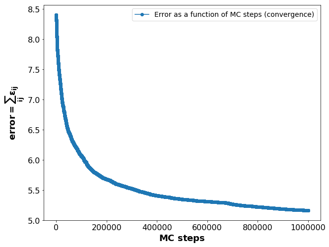

```python
_seed = 103
np.random.seed(_seed)

dept_num = 3
store_num = 1
dept_data=filter_for_store_dept(store_num, dept_num, raw_data)

########## Calibration aka. training

Y = []
X = []
len_pred_array = 39

for n in range(len(sales), 2*39 - 1, -1):
    Y.append(sales[(n-len_pred_array):n])
    X.append(sales[(n-2*len_pred_array):(n-len_pred_array)])


X = np.matrix(X).transpose()
X = np.vstack([[1 for t in range(X.shape[1])], X])
Y = np.matrix(Y).transpose()

theta = np.zeros([Y.shape[0], X.shape[0]])

print 'initial error = ', getError(theta, X, Y)

num_mc = 1000000
dTheta = 0.01
min_theta = -2
max_theta = +2
errors = optimize(theta, X, Y,
                  num_mc=num_mc,
                  dTheta=dTheta,
                  min_theta = min_theta,
                  max_theta = max_theta,
                  )
fig, ax =plt.subplots(1,1, figsize=[10,8])

ax.plot(errors, '-o', label='Error as a function of MC steps (convergence)')
ax.set_xlabel(r'$\mathbf{MC\,\,steps}$', fontsize=18)
ax.set_ylabel(r'$\mathbf{error = \sum_{ij} \epsilon_{ij}}$', fontsize=18)
ax.tick_params(axis='x', labelsize=16)
ax.tick_params(axis='y', labelsize=16)
ax.legend(fontsize=14 )

print 'error after optm. = ', getError(theta, X, Y)
print 'num_mc = ', num_mc
print 'min_theta = ', min_theta
print 'max_theta = ', max_theta
print 'dTheta = ', dTheta

plt.show()
```

## Predictions:

### Finally the model that is trained using the sales of the first $\mathbf{100}$ weeks is used to predict the last $\mathbf{39}$:

```
----validation error =  6.5570293382
```

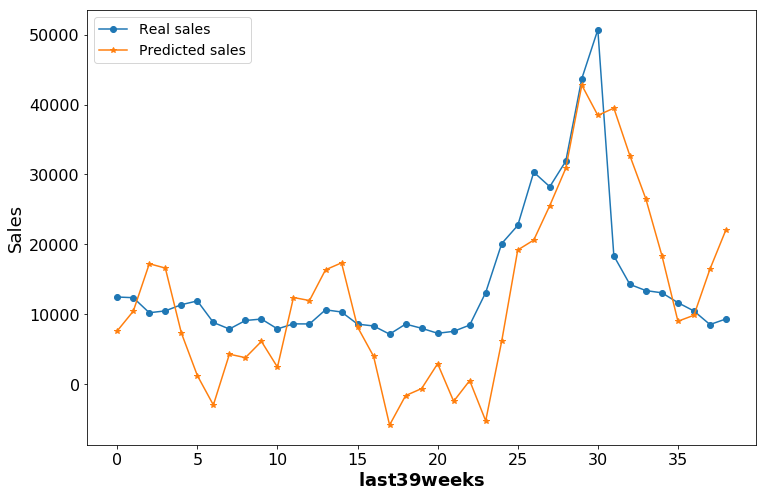

```python
####### validation



sales= dept_data['Weekly_Sales'].values
#sales= sales[:100]

variance_validation = (0.0 + np.max(sales)- np.min(sales))
avrg_validation =  np.average(sales)

sales =  (sales - avrg_validation)/\
        (0.0 + variance_validation)


Y = []
X = []
for n in range(len(sales), 2*len_pred_array - 1, -1):
    Y.append(sales[(n-len_pred_array):n])
    X.append(sales[(n-2*len_pred_array):(n-len_pred_array)])

X = np.matrix(X).transpose()
X = np.vstack([[1 for t in range(X.shape[1])], X])
Y = np.matrix(Y).transpose()


Y_predicted=theta.dot(X)

## "0" because it corresponds to the last 39 weeks we would like to forecast
validation_col =0

fig, ax =plt.subplots(1,1, figsize=[12, 8])
ax.plot(Y[:, validation_col] * variance_validation + avrg_validation , '-o', label='Real sales')
ax.plot(Y_predicted[:, validation_col]* variance + avrg, '-*', label ='Predicted sales')

ax.set_xlabel(r'$\mathbf{last 39 weeks}$', fontsize=18)
ax.set_ylabel('Sales', fontsize=18)
ax.tick_params(axis='x', labelsize=16)
ax.tick_params(axis='y', labelsize=16)
ax.legend(fontsize=14 )


print '----validation error = ' , getError(theta, X[:,0:20], Y[:, 0:20])

plt.show()
```

## Other departments:

```
initial error =  8.07037688882
error after optm. =  3.99647755614
num_mc =  2000000
min_theta =  -2.0
max_theta =  2.0
dTheta =  0.01
```

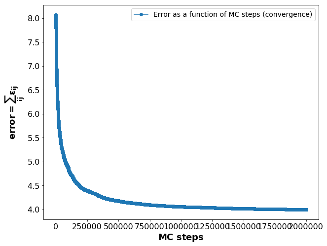

```python
_seed = 103
np.random.seed(_seed)

dept_num = 5
store_num = 15
## filter for the above department
dept_data=filter_for_store_dept(store_num, dept_num, raw_data)

########## Calibration aka. training

Y = []
X = []
len_pred_array = 39

for n in range(len(sales), 2*39 - 1, -1):
    Y.append(sales[(n-len_pred_array):n])
    X.append(sales[(n-2*len_pred_array):(n-len_pred_array)])


X = np.matrix(X).transpose()
X = np.vstack([[1 for t in range(X.shape[1])], X])
Y = np.matrix(Y).transpose()

theta = np.zeros([Y.shape[0], X.shape[0]])

print 'initial error = ', getError(theta, X, Y)

num_mc = 2000000
dTheta = 0.01
min_theta = -2.0
max_theta = +2.0
errors = optimize(theta, X, Y,
                  num_mc=num_mc,
                  dTheta=dTheta,
                  min_theta = min_theta,
                  max_theta = max_theta,
                  )
fig, ax =plt.subplots(1,1, figsize=[10,8])

ax.plot(errors, '-o', label='Error as a function of MC steps (convergence)')
ax.set_xlabel(r'$\mathbf{MC\,\,steps}$', fontsize=18)
ax.set_ylabel(r'$\mathbf{error = \sum_{ij} \epsilon_{ij}}$', fontsize=18)
ax.tick_params(axis='x', labelsize=16)
ax.tick_params(axis='y', labelsize=16)
ax.legend(fontsize=14 )

print 'error after optm. = ', getError(theta, X, Y)
print 'num_mc = ', num_mc
print 'min_theta = ', min_theta
print 'max_theta = ', max_theta
print 'dTheta = ', dTheta

plt.show()
```

```
----validation error =  2.82273755935
```

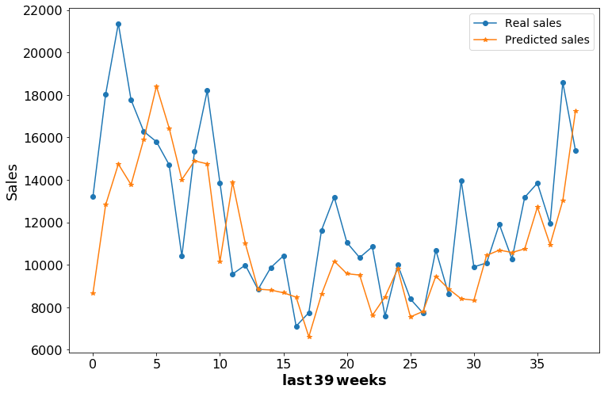

```python
####### validation



sales= dept_data['Weekly_Sales'].values
#sales= sales[:100]

variance_validation = (0.0 + np.max(sales)- np.min(sales))
avrg_validation =  np.average(sales)

sales =  (sales - avrg_validation)/\
        (0.0 + variance_validation)


Y = []
X = []
for n in range(len(sales), 2*len_pred_array - 1, -1):
    Y.append(sales[(n-len_pred_array):n])
    X.append(sales[(n-2*len_pred_array):(n-len_pred_array)])

X = np.matrix(X).transpose()
X = np.vstack([[1 for t in range(X.shape[1])], X])
Y = np.matrix(Y).transpose()


Y_predicted=theta.dot(X)

## "0" because it corresponds to the last 39 weeks we would like to forecast
validation_col =0

fig, ax =plt.subplots(1,1, figsize=[12, 8])
ax.plot(Y[:, validation_col] * variance_validation + avrg_validation , '-o', label='Real sales')
ax.plot(Y_predicted[:, validation_col]* variance + avrg, '-*', label ='Predicted sales')

ax.set_xlabel(r'$\mathbf{last\,39\, weeks}$', fontsize=18)
ax.set_ylabel('Sales', fontsize=18)
ax.tick_params(axis='x', labelsize=16)
ax.tick_params(axis='y', labelsize=16)
ax.legend(fontsize=14 )


print '----validation error = ' , getError(theta, X[:,0:20], Y[:, 0:20])

plt.show()
```

**To get an idea of theta and how it looks:**

```python
theta
```

```
array([[ 0.06, -0.08, -0.13, ...,  0.08,  0.1 ,  0.22],
       [ 0.07, -0.12, -0.05, ...,  0.37,  0.1 ,  0.16],
       [ 0.09, -0.21, -0.09, ..., -0.19,  0.39,  0.12],
       ...,
       [-0.02, -0.04,  0.01, ...,  0.01,  0.  ,  0.  ],
       [-0.02,  0.03, -0.05, ..., -0.01,  0.03, -0.05],
       [-0.03,  0.05,  0.02, ...,  0.04,  0.  ,  0.03]])
```

## Final Remarks:

This is a of-course an afternoon spare time with real world data and optimization. There are certainly much rigorous and faster approaches which are well established....

The ideas behind the current approach are probably borrowed from physical problems such as:

- Potts Model (https://en.wikipedia.org/wiki/Potts_model)
- Classical Monte Carlo and Metropolis-algorithm (https://en.wikipedia.org/wiki/Monte_Carlo)